# Interpolation of REPHY data

The goal is to interpolate REPHY data – nutrient and oxygen concentrations – when and where fishing operation occured. It means interpolate the variables of interest in space and time. We intend to do so using the Bayesian framework INLA.

```r
library(renv)
renv::load()
library(targets)
library(here)
tar_config_set(
  store = here::here("_targets")
)
library(ggplot2)
library(dplyr)
library(sf)
library(patchwork)
devtools::load_all()
riversea::nice_theme()
knitr::opts_chunk$set(autodep = TRUE)
```

## Presentation of the data

Here is the REPHY data that we have collected and cleaned.

```r
rephy_data <- tar_read(rephy_data_surface)
str(rephy_data)
```

```
tibble [71,984 × 14] (S3: tbl_df/tbl/data.frame)
 $ site_id        : num [1:71984] 1e+06 1e+06 1e+06 1e+06 1e+06 ...
 $ site_label     : chr [1:71984] "Strouanne" "Strouanne" "Strouanne" "Strouanne" ...
 $ sample_id      : num [1:71984] 50157 50157 50158 50158 50159 ...
 $ passage_id     : num [1:71984] 46823 46823 46824 46824 46825 ...
 $ date           : Date[1:71984], format: "1989-02-09" "1989-02-09" ...
 $ depth          : num [1:71984] 0.5 0.5 0.5 0.5 0.5 0.5 0.5 0.5 0.5 0.5 ...
 $ depth_unit     : chr [1:71984] "m" "m" "m" "m" ...
 $ longitude      : num [1:71984] 1.68 1.68 1.68 1.68 1.68 ...
 $ latitude       : num [1:71984] 50.9 50.9 50.9 50.9 50.9 ...
 $ parameter_code : chr [1:71984] "NH4" "OXYGENE" "NH4" "OXYGENE" ...
 $ parameter_label: chr [1:71984] "Ammonium" "Oxygène dissous" "Ammonium" "Oxygène dissous" ...
 $ value          : num [1:71984] 0.15 9.23 0.15 7.39 0.15 ...
 $ unit           : chr [1:71984] "µmol.l-1" "mg.l-1" "µmol.l-1" "mg.l-1" ...
 $ salinity       : num [1:71984] 34.1 34.1 34.7 34.7 35 35 33.9 34.2 35.7 35.7 ...
```

For more information see Overview of REPHY data. And, here is the fishing operation data.

```r
foodwebs <- tar_read(foodweb_structure) |>
  dplyr::filter(survey %in% c("nurse", "pomet"))
```

This interpolation exercise is only concerned with sea-survey operations (`nurse` and `pomet`), not river-survey ones – REPHY monitors marine and estuarine chemistry, which has no bearing hundreds of kilometers up a river.

Before interpolating anything, we start with a simple picture of where and when the two datasets overlap: REPHY nutrient and oxygen stations on one side, fishing operations from the food web data on the other.

### Spatial coverage

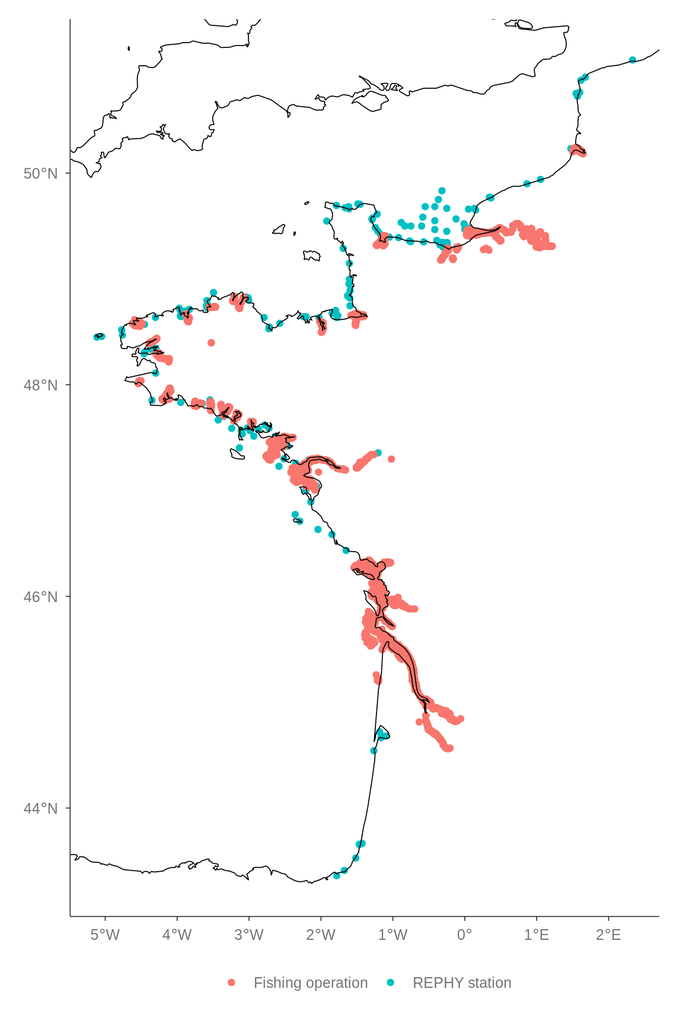

```r
sites <- dplyr::bind_rows(
  rephy_data |>
    dplyr::distinct(longitude, latitude) |>
    dplyr::mutate(source = "REPHY station"),
  foodwebs |>
    dplyr::distinct(longitude, latitude) |>
    dplyr::mutate(source = "Fishing operation")
)

ggplot(sites, aes(x = longitude, y = latitude, color = source)) +
  geom_point() +
  geom_sf(data = coastline(), inherit.aes = FALSE, linewidth = 0.3) +
  coord_sf(xlim = range(sites$longitude), ylim = range(sites$latitude)) +
  labs(x = NULL, y = NULL, color = NULL) +
  theme(panel.grid = element_blank())
```

Fishing operations are much more numerous and spatially diffuse than REPHY stations, which are fixed monitoring points. Interpolation will need to be based on REPHY stations that are reasonably close to fishing operations.

### Temporal coverage

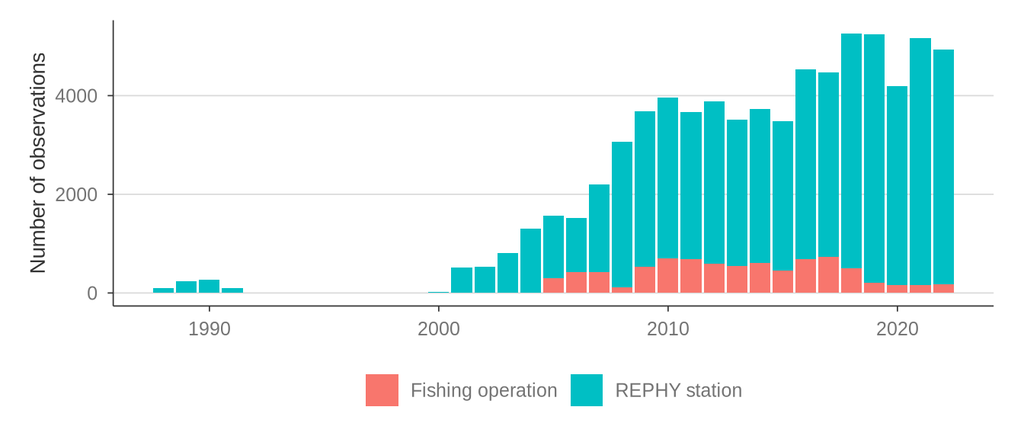

```r
yearly_counts <- dplyr::bind_rows(
  rephy_data |>
    dplyr::mutate(year = lubridate::year(date)) |>
    dplyr::count(year, name = "n") |>
    dplyr::mutate(source = "REPHY station"),
  foodwebs |>
    dplyr::count(year, name = "n") |>
    dplyr::mutate(source = "Fishing operation")
)

ggplot(yearly_counts, aes(x = year, y = n, fill = source)) +
  geom_col(position = "identity") +
  scale_x_continuous(breaks = scales::breaks_pretty()) +
  labs(x = NULL, y = "Number of observations", fill = NULL)
```

## Interpolation model

Each REPHY parameter is interpolated with an additive spatio-temporal model, fit with INLA: a spatial Matérn field (via the SPDE approximation), a smooth year trend, and a cyclic month effect to capture seasonality. Values are modelled on the log scale, since concentrations are strictly positive and right-skewed.

$$\log(\text{nutrient}) = \text{SPDE}_\text{2D} + \text{year}_\text{RW}
+ \text{month}_\text{RW}$$

```r
rephy_filtered <- tar_read(rephy_data_sample)
```

### Spatial mesh

We build a mesh around REPHY stations and fishing operations. Its boundary follows the coastline (a non-convex hull) rather than the convex hull of the points, which would otherwise includes the land between the Atlantic and Channel clusters. It’s a `targets` pipeline target (`rephy_mesh`), not built here, so it’s reusable from other notebooks without recomputing it.

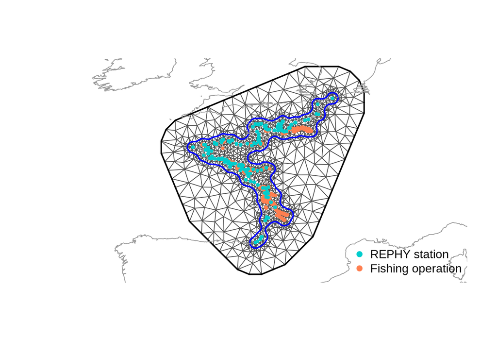

```r
mesh <- tar_read(rephy_mesh)
plot(mesh, main = "")
plot(sf::st_geometry(coastline()), add = TRUE, col = "grey60")
points(
  foodwebs$longitude,
  foodwebs$latitude,
  col = "coral",
  pch = 19,
  cex = 0.5
)
points(
  rephy_filtered$longitude,
  rephy_filtered$latitude,
  col = "cyan3",
  pch = 19,
  cex = 0.5
)
legend(
  "bottomright",
  legend = c("REPHY station", "Fishing operation"),
  col = c("cyan3", "coral"),
  pch = 19,
  bty = "n"
)
```

This is the mesh the model is going to work with. Next, we fit first model and evaluate them with cross-validation.

### Cross-validation

```r
n_fold <- 5
```

We evaluate the model on each of the four parameters with leave-station-out k-fold cross-validation. Stations are split into 5 groups, and each group is predicted from a model trained on the other stations only. This tests spatial generalization and doesn’t let a station’s other-year data leak into the test fold.

We compare our model performence (RMSE, MAE and correlation) against a naive baseline prediction: the training fold’s mean.

```r
set.seed(1)
cv_all <- purrr::map_dfr(unique(rephy_filtered$parameter_code), \(parameter) {
  d_param <- rephy_filtered |> dplyr::filter(parameter_code == parameter)
  cv <- cv_rephy_spde(d_param, mesh, k = n_fold)
  cv$parameter_code <- parameter
  cv
})

cv_all |>
  dplyr::group_by(parameter_code) |>
  dplyr::group_modify(\(cv, ...) {
    metrics <- rephy_cv_metrics(cv)
    baseline <- rephy_cv_metrics(cv, pred_col = "pred_baseline")
    data.frame(
      model = c("SPDE", "Naive baseline"),
      rmse = c(metrics$rmse, baseline$rmse),
      mae = c(metrics$mae, baseline$mae),
      cor = c(metrics$cor, baseline$cor)
    )
  }) |>
  dplyr::ungroup() |>
  knitr::kable(digits = 2)
```

| parameter_code | model | rmse | mae | cor |
| --- | --- | --- | --- | --- |
| NH4 | SPDE | 1.22 | 0.95 | 0.44 |
| NH4 | Naive baseline | 1.35 | 1.08 | -0.09 |
| NO3+NO2 | SPDE | 1.45 | 1.15 | 0.71 |
| NO3+NO2 | Naive baseline | 2.04 | 1.63 | -0.11 |
| OXYGENE | SPDE | 0.14 | 0.09 | 0.58 |
| OXYGENE | Naive baseline | 0.17 | 0.12 | -0.04 |
| PO4 | SPDE | 0.83 | 0.62 | 0.66 |
| PO4 | Naive baseline | 1.11 | 0.93 | -0.07 |

Across parameters, the SPDE model has lower log-scale RMSE than the naive baseline and correlates positively with observed values, where the baseline is essentially uncorrelated by construction. The spatio-temporal structure is clearly adding information, even if there’s room to improve.

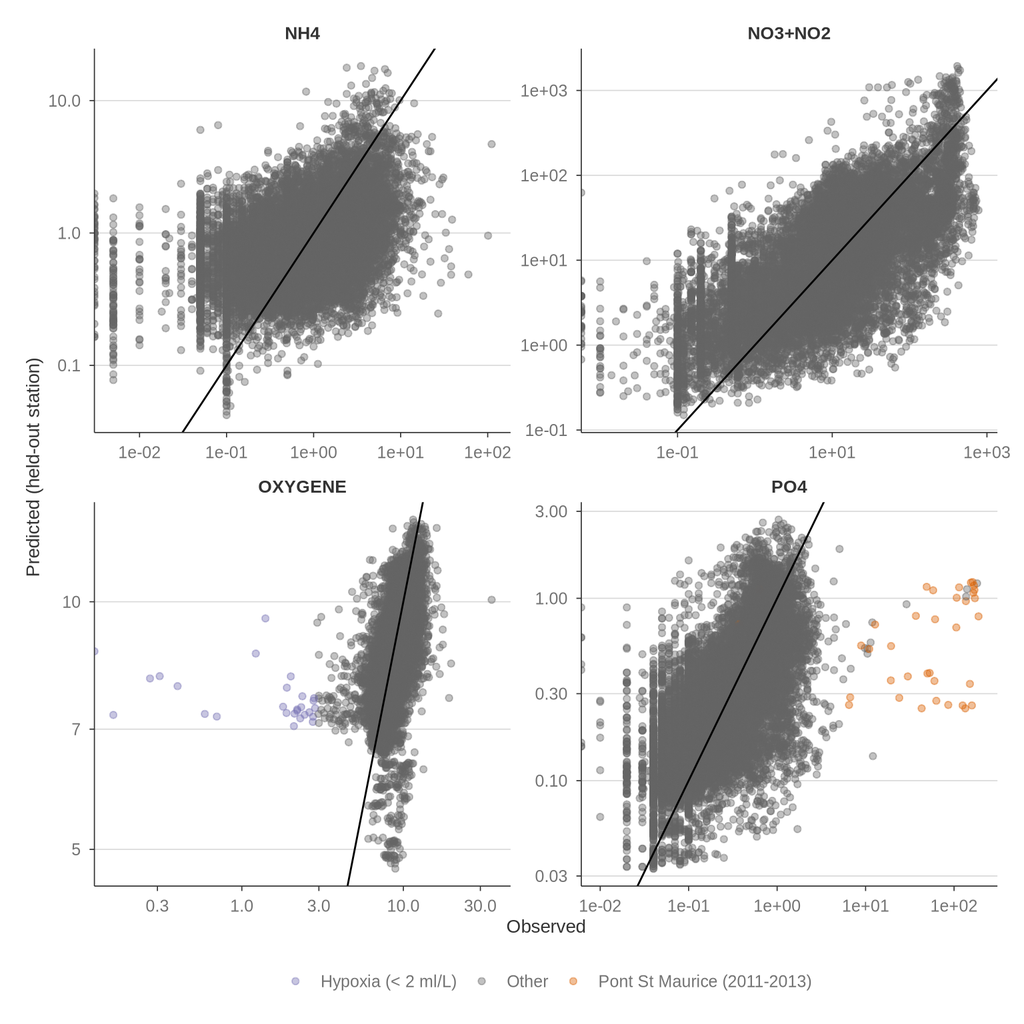

```r
cv_all <- cv_all |>
  dplyr::mutate(
    highlight = dplyr::case_when(
      parameter_code == "PO4" & site_id == 22044027 & year %in% 2011:2013 ~
        "Pont St Maurice (2011-2013)",
      parameter_code == "OXYGENE" & value < 2 * 1.42903 ~ "Hypoxia (< 2 ml/L)",
      TRUE ~ "Other"
    )
  )

ggplot(cv_all, aes(x = value, y = pred, color = highlight)) +
  geom_point(alpha = 0.4) +
  geom_abline(slope = 1, intercept = 0) +
  scale_x_log10() +
  scale_y_log10() +
  scale_color_manual(
    values = c(
      "Other" = "grey40",
      "Pont St Maurice (2011-2013)" = "#d95f02",
      "Hypoxia (< 2 ml/L)" = "#7570b3"
    )
  ) +
  facet_wrap(~parameter_code, scales = "free") +
  labs(x = "Observed", y = "Predicted (held-out station)", color = NULL)
```

The highlighted points, on the PO4 panel, show an anomaly at the station Pont St Maurice, that cannot be predicted by its nearest neighbour. This shows that this point cannot be predicted by a smooth model as they are very localized in space and time. Excluding these, we see that the predictions of our model are quite reasonnable.

On the OXYGENE panel, the highlighted points are hypoxia events (< 2 ml/L, i.e. < 2.86 mg/L Diaz and Rosenberg (2008)) unpredictable from neighbouring stations when the station itself is held out.

We will use yearly averages rather than raw values in the next modelling steps, we also plot the same predictions averaged per year (observed and predicted).

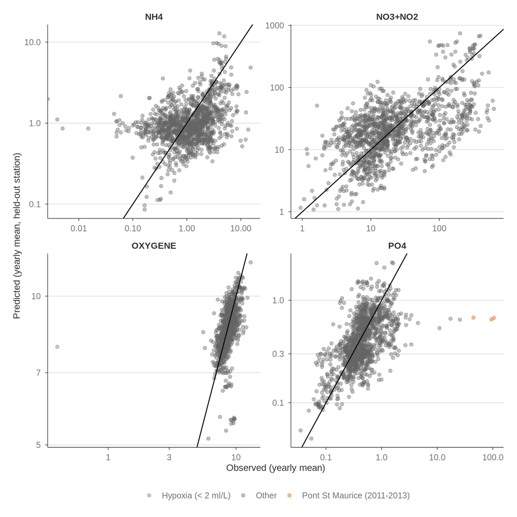

```r
cv_yearly <- cv_all |>
  dplyr::summarise(
    value = mean(value),
    pred = mean(pred),
    .by = c(parameter_code, site_id, site_label, year)
  ) |>
  dplyr::mutate(
    highlight = dplyr::case_when(
      parameter_code == "PO4" & site_id == 22044027 & year %in% 2011:2013 ~
        "Pont St Maurice (2011-2013)",
      parameter_code == "OXYGENE" & value < 2 * 1.42903 ~ "Hypoxia (< 2 ml/L)",
      TRUE ~ "Other"
    )
  )

ggplot(cv_yearly, aes(x = value, y = pred, color = highlight)) +
  geom_point(alpha = 0.4) +
  geom_abline(slope = 1, intercept = 0) +
  scale_x_log10() +
  scale_y_log10() +
  scale_color_manual(
    values = c(
      "Other" = "grey40",
      "Pont St Maurice (2011-2013)" = "#d95f02",
      "Hypoxia (< 2 ml/L)" = "#7570b3"
    )
  ) +
  facet_wrap(~parameter_code, scales = "free") +
  labs(
    x = "Observed (yearly mean)",
    y = "Predicted (yearly mean, held-out station)",
    color = NULL
  )
```

We see that mechanically averaging per year remove most of the noise. On yearly average our model performs more than fine so we will use this interpolation model to get environmental values at our fishing operations. But before doing so, we will check the structure of the model residuals.

### Residual structure

#### Temporal structure

We check whether the CV residuals still carry spatial or temporal structure.

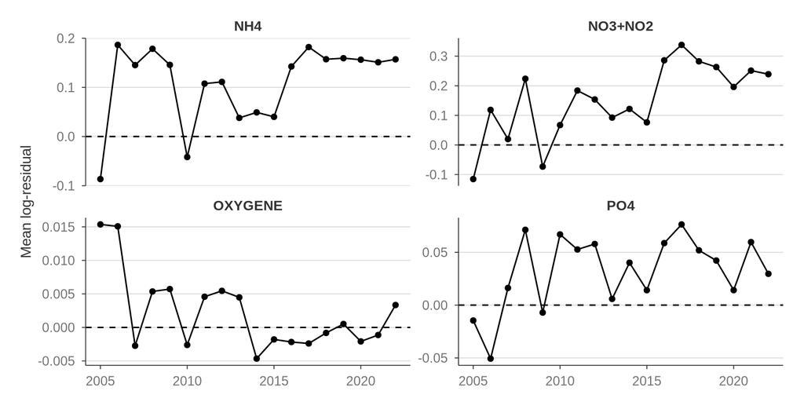

```r
cv_resid <- cv_all |>
  dplyr::filter(value > 0) |>
  dplyr::mutate(resid = log(pred) - log(value))

year_resid <- cv_resid |>
  dplyr::summarise(resid = mean(resid), .by = c(parameter_code, year))
month_resid <- cv_resid |>
  dplyr::summarise(resid = mean(resid), .by = c(parameter_code, month))

ggplot(year_resid, aes(x = year, y = resid)) +
  geom_hline(yintercept = 0, linetype = "dashed") +
  geom_line() +
  geom_point() +
  facet_wrap(~parameter_code, scales = "free_y") +
  labs(x = NULL, y = "Mean log-residual")
```

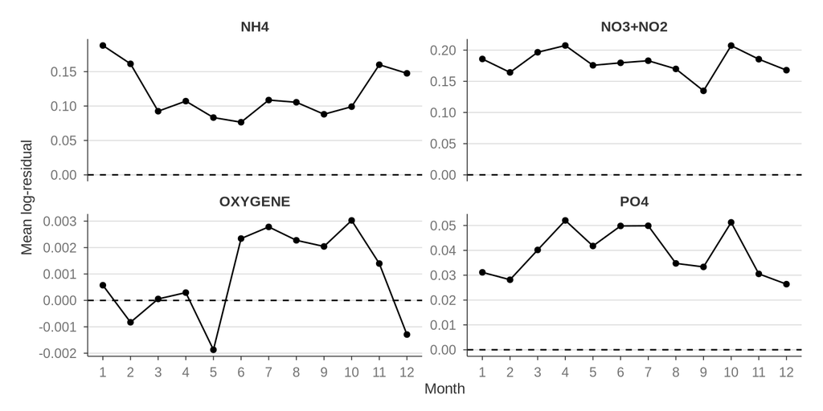

```r
ggplot(month_resid, aes(x = month, y = resid)) +
  geom_hline(yintercept = 0, linetype = "dashed") +
  geom_line() +
  geom_point() +
  scale_x_continuous(breaks = 1:12) +
  facet_wrap(~parameter_code, scales = "free_y") +
  labs(x = "Month", y = "Mean log-residual")
```

#### Spatial structure

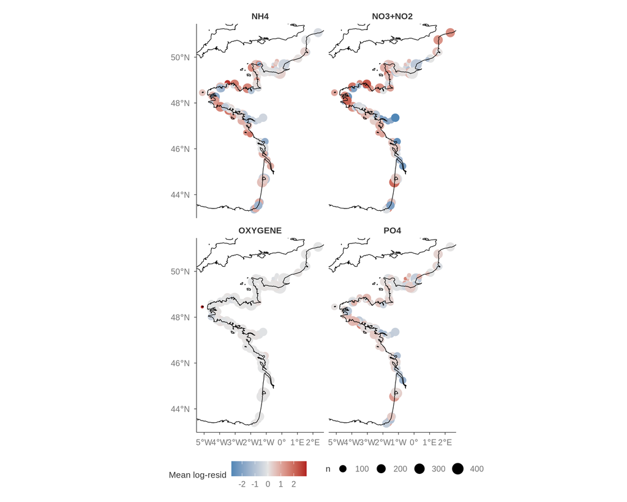

```r
station_resid <- cv_resid |>
  dplyr::summarise(
    resid = mean(resid),
    n = dplyr::n(),
    .by = c(parameter_code, site_id, longitude, latitude)
  )

ggplot(station_resid, aes(x = longitude, y = latitude, color = resid, size = n)) +
  geom_point(alpha = 1) +
  geom_sf(data = coastline(), inherit.aes = FALSE, linewidth = 0.3) +
  coord_sf(
    xlim = range(station_resid$longitude), ylim = range(station_resid$latitude)
  ) +
  scale_color_gradient2(
    low = "steelblue",
    mid = "grey90",
    high = "firebrick",
    midpoint = 0
  ) +
  facet_wrap(~parameter_code) +
  labs(x = NULL, y = NULL, color = "Mean log-resid", size = "n") +
  theme(panel.grid = element_blank())
```

## Refining the model

### Salinity

REPHY and some fishing operations also measures salinity at most stations, so we can use it to inform our predictions. In particular this may help with the understimation issue we observe in estuaries.

```r
rephy_filtered |>
  dplyr::summarise(
    n = dplyr::n(),
    n_salinity = sum(!is.na(salinity)),
    pct_salinity = round(100 * mean(!is.na(salinity)), 1),
    .by = parameter_code
  ) |>
  knitr::kable()
```

| parameter_code | n | n_salinity | pct_salinity |
| --- | --- | --- | --- |
| OXYGENE | 22307 | 22266 | 99.8 |
| NO3+NO2 | 15206 | 15014 | 98.7 |
| PO4 | 15264 | 15070 | 98.7 |
| NH4 | 15054 | 14863 | 98.7 |

Coverage is close to complete for all four parameters. We next plot the relationship between our parameters and salinity.

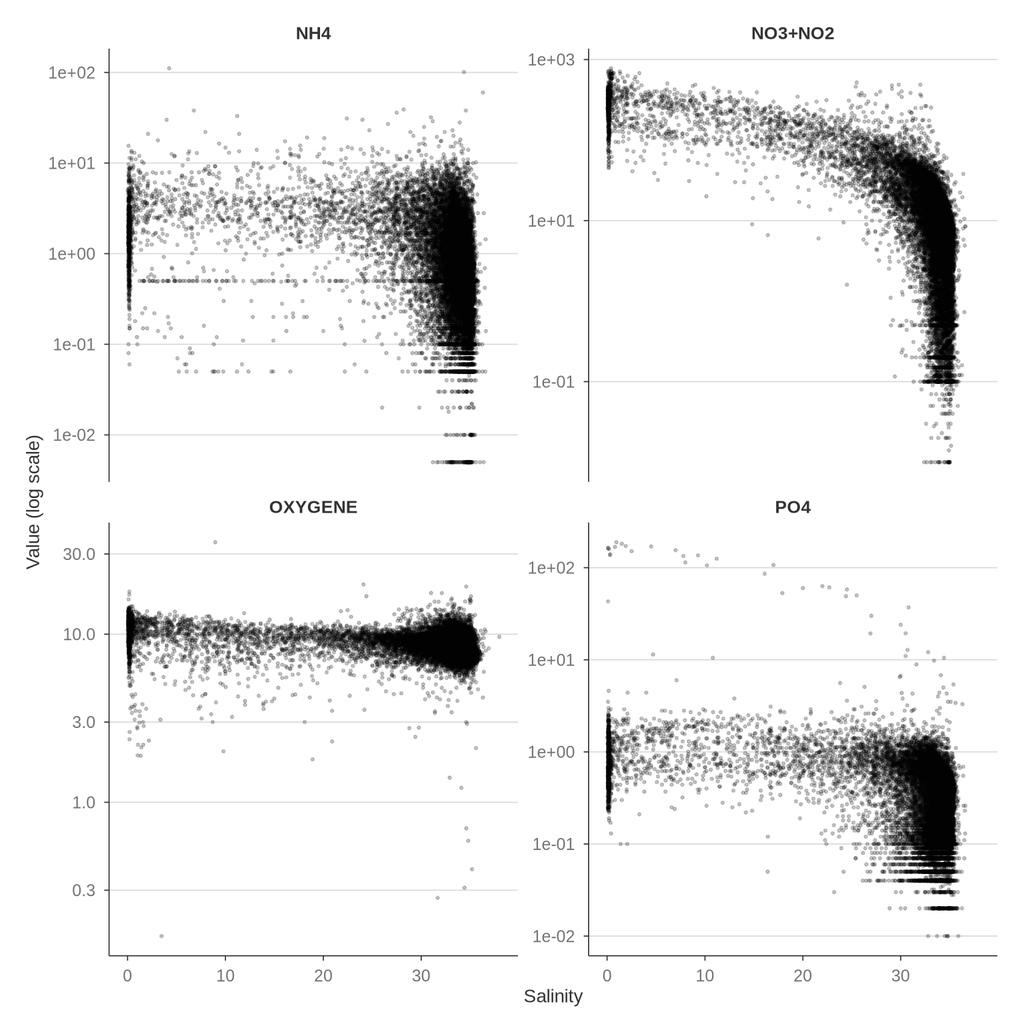

```r
sal_data <- rephy_filtered |> dplyr::filter(!is.na(salinity), value > 0)

ggplot(sal_data, aes(x = salinity, y = value)) +
  geom_point(alpha = 0.2, size = 0.5) +
  scale_y_log10() +
  facet_wrap(~parameter_code, scales = "free_y") +
  labs(x = "Salinity", y = "Value (log scale)")
```

We see a strong relationship, and it’s clearly not a straight line on the log scale – so we compare the baseline model against three ways of adding salinity: a linear term, a quadratic term, and a smooth term (a P-spline: a cubic B-spline basis with an RW2 smoothness penalty on its coefficients) to capture that curvature.

$$\log(\text{nutrient}) = \text{SPDE}_\text{2D} + \text{year}_\text{RW}
+ \text{month}_\text{RW} + \beta \cdot \text{salinity}$$

$$\log(\text{nutrient}) = \text{SPDE}_\text{2D} + \text{year}_\text{RW}
+ \text{month}_\text{RW} + \beta_1 \cdot \text{salinity}
+ \beta_2 \cdot \text{salinity}^2$$

$$\log(\text{nutrient}) = \text{SPDE}_\text{2D} + \text{year}_\text{RW}
+ \text{month}_\text{RW} + \text{salinity}_\text{P-spline}$$

**Note**

We use linear scale for salinity in the model, not logged. We tested `log(salinity)` and found that raw salinity performed better on every parameter.

We compare all four models with the same leave-station-out cross-validation as before, on the same data (samples with a matched salinity value), so the only thing that differs between them is the covariate.

```r
rephy_sal <- rephy_filtered |> dplyr::filter(!is.na(salinity))

set.seed(1)
cv_base_sal <- purrr::map_dfr(unique(rephy_sal$parameter_code), \(parameter) {
  d_param <- rephy_sal |>
    dplyr::filter(parameter_code == parameter)
  cv <- cv_rephy_spde(d_param, mesh, k = n_fold)
  cv$parameter_code <- parameter
  cv
})

set.seed(1)
cv_salinity <- purrr::map_dfr(unique(rephy_sal$parameter_code), \(parameter) {
  d_param <- rephy_sal |>
    dplyr::filter(parameter_code == parameter)
  cv <- cv_rephy_spde(
    d_param, mesh,
    predict_fn = predict_rephy_spde_salinity, k = n_fold
  )
  cv$parameter_code <- parameter
  cv
})
```

```r
set.seed(1)
cv_salinity_quadratic <- purrr::map_dfr(unique(rephy_sal$parameter_code), \(parameter) {
  d_param <- rephy_sal |>
    dplyr::filter(parameter_code == parameter)
  cv <- cv_rephy_spde(
    d_param, mesh,
    predict_fn = predict_rephy_spde_salinity_quadratic, k = n_fold
  )
  cv$parameter_code <- parameter
  cv
})
```

```r
set.seed(1)
cv_salinity_smooth <- purrr::map_dfr(unique(rephy_sal$parameter_code), \(parameter) {
  d_param <- rephy_sal |>
    dplyr::filter(parameter_code == parameter)
  cv <- cv_rephy_spde(
    d_param, mesh,
    predict_fn = predict_rephy_spde_salinity_smooth, k = n_fold
  )
  cv$parameter_code <- parameter
  cv
})
```

To check that the smooth term isn’t just overfitting we also compute WAIC from a single full-data fit per model.

```r
rephy_criteria <- purrr::map_dfr(unique(rephy_sal$parameter_code), \(parameter) {
  d_param <- rephy_sal |> dplyr::filter(parameter_code == parameter)
  dplyr::bind_rows(
    rephy_model_criteria(predict_rephy_spde(d_param, d_param, mesh)) |>
      dplyr::mutate(model = "Baseline"),
    rephy_model_criteria(predict_rephy_spde_salinity(d_param, d_param, mesh)) |>
      dplyr::mutate(model = "Salinity (linear)"),
    rephy_model_criteria(predict_rephy_spde_salinity_quadratic(d_param, d_param, mesh)) |>
      dplyr::mutate(model = "Salinity (quadratic)"),
    rephy_model_criteria(predict_rephy_spde_salinity_smooth(d_param, d_param, mesh)) |>
      dplyr::mutate(model = "Salinity (smooth)")
  ) |>
    dplyr::mutate(parameter_code = parameter)
})
```

```r
dplyr::bind_rows(
  cv_base_sal |>
    dplyr::group_by(parameter_code) |>
    dplyr::group_modify(\(cv, ...) as.data.frame(rephy_cv_metrics(cv))) |>
    dplyr::mutate(model = "Baseline"),
  cv_salinity |>
    dplyr::group_by(parameter_code) |>
    dplyr::group_modify(\(cv, ...) as.data.frame(rephy_cv_metrics(cv))) |>
    dplyr::mutate(model = "Salinity (linear)"),
  cv_salinity_quadratic |>
    dplyr::group_by(parameter_code) |>
    dplyr::group_modify(\(cv, ...) as.data.frame(rephy_cv_metrics(cv))) |>
    dplyr::mutate(model = "Salinity (quadratic)"),
  cv_salinity_smooth |>
    dplyr::group_by(parameter_code) |>
    dplyr::group_modify(\(cv, ...) as.data.frame(rephy_cv_metrics(cv))) |>
    dplyr::mutate(model = "Salinity (smooth)")
) |>
  dplyr::ungroup() |>
  dplyr::left_join(
    rephy_criteria |> dplyr::select(parameter_code, model, waic),
    by = c("parameter_code", "model")
  ) |>
  dplyr::mutate(is_best = waic == min(waic), .by = parameter_code) |>
  dplyr::arrange(parameter_code, model) |>
  dplyr::transmute(
    parameter_code,
    model,
    rmse = sprintf("%.2f", rmse),
    mae = sprintf("%.2f", mae),
    waic = sprintf("%.1f", waic),
    is_best
  ) |>
  dplyr::mutate(
    dplyr::across(
      c(model, rmse, mae, waic),
      \(x) dplyr::if_else(is_best, paste0("<strong>", x, "</strong>"), x)
    )
  ) |>
  dplyr::select(-is_best) |>
  knitr::kable(escape = FALSE)
```

| parameter_code | model | rmse | mae | waic |
| --- | --- | --- | --- | --- |
| NH4 | Baseline | 1.21 | 0.94 | 41188.7 |
| NH4 | Salinity (linear) | 1.17 | 0.91 | 41085.3 |
| NH4 | Salinity (quadratic) | 1.13 | 0.87 | 40786.3 |
| NH4 | **Salinity (smooth)** | **1.13** | **0.88** | **40522.5** |
| NO3+NO2 | Baseline | 1.47 | 1.15 | 42839.9 |
| NO3+NO2 | Salinity (linear) | 1.24 | 0.96 | 41983.6 |
| NO3+NO2 | Salinity (quadratic) | 1.11 | 0.85 | 40310.6 |
| NO3+NO2 | **Salinity (smooth)** | **1.01** | **0.75** | **38856.4** |
| OXYGENE | Baseline | 0.14 | 0.09 | 28567.1 |
| OXYGENE | Salinity (linear) | 0.14 | 0.09 | 20350.7 |
| OXYGENE | **Salinity (quadratic)** | **0.14** | **0.09** | **17296.0** |
| OXYGENE | Salinity (smooth) | 0.15 | 0.09 | 77621.5 |
| PO4 | Baseline | 0.83 | 0.62 | 29643.9 |
| PO4 | Salinity (linear) | 0.81 | 0.61 | 29644.4 |
| PO4 | Salinity (quadratic) | 0.76 | 0.56 | 29114.8 |
| PO4 | **Salinity (smooth)** | **0.73** | **0.54** | **29026.7** |

#### Marginal salinity effect

To check that the P-spline is actually behaving like a smooth function of salinity (and not just overfitting), we plot its marginal effect.

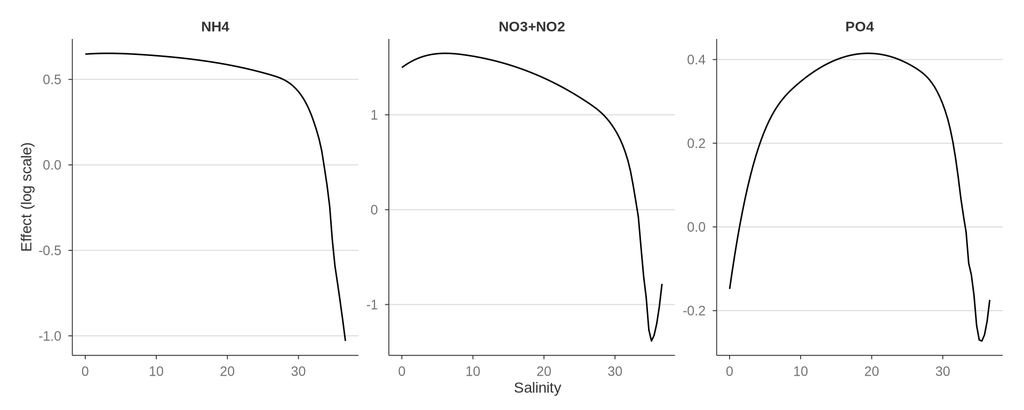

```r
spline_curve <- function(fit_obj) {
  boundary <- attr(fit_obj$bs_basis, "Boundary.knots")
  salinity <- seq(boundary[1], boundary[2], length.out = 100)
  mean <- predict(fit_obj$bs_basis, salinity) %*% fit_obj$fit$summary.random$spline$mean
  data.frame(salinity = salinity, mean = as.vector(mean))
}

salinity_marginal <- dplyr::bind_rows(
  "NH4" = spline_curve(tar_read(rephy_fit_nh4)),
  "NO3+NO2" = spline_curve(tar_read(rephy_fit_no3_no2)),
  "PO4" = spline_curve(tar_read(rephy_fit_po4)),
  .id = "parameter_code"
)

ggplot(salinity_marginal, aes(x = salinity, y = mean)) +
  geom_line() +
  facet_wrap(~parameter_code, scales = "free_y") +
  labs(x = "Salinity", y = "Effect (log scale)")
```

The curves are smooth throughout – an earlier RW1-over-binned-salinity version of this same model produced a visibly noisier curve, which is why we moved to the P-spline.

### Spatial residuals

The residual-structure map above showed a set of estuarine stations consistently under-predicted. We rebuild the same map, baseline vs. smooth salinity (the model we’re keeping), on the same station set so the two rows are directly comparable.

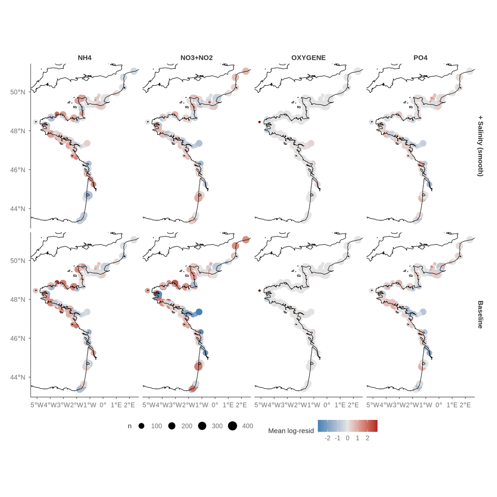

```r
resid_compare <- dplyr::bind_rows(
  cv_base_sal |> dplyr::mutate(model = "Baseline"),
  cv_salinity_smooth |> dplyr::mutate(model = "+ Salinity (smooth)")
) |>
  dplyr::filter(value > 0) |>
  dplyr::mutate(resid = log(pred) - log(value)) |>
  dplyr::summarise(
    resid = mean(resid),
    n = dplyr::n(),
    .by = c(model, parameter_code, site_id, longitude, latitude)
  )

ggplot(resid_compare, aes(x = longitude, y = latitude, color = resid, size = n)) +
  geom_point(alpha = 1) +
  geom_sf(data = coastline(), inherit.aes = FALSE, linewidth = 0.3) +
  coord_sf(
    xlim = range(resid_compare$longitude), ylim = range(resid_compare$latitude)
  ) +
  scale_color_gradient2(
    low = "steelblue",
    mid = "grey90",
    high = "firebrick",
    midpoint = 0
  ) +
  facet_grid(model ~ parameter_code) +
  labs(x = NULL, y = NULL, color = "Mean log-resid", size = "n") +
  theme(panel.grid = element_blank())
```

We see a clear improvement of the model in the estuaries. Next, we move to predicting nutrient values at our fishing operations.

## Predicting at fishing operations

This is our goal. Predict nutrient values at every `nurse` and `pomet` fishing operation. We use the smooth-salinity model for NH4, NO3+NO2 and PO4 – OXYGENE is dropped. Each parameter is fit once on the full salinity-complete REPHY dataset, then predicted at every operation. `pomet` operations use their own measured salinity where available; the rest (all `nurse` and 4% of `pomet`) fall back to a space-time-only prediction for that operation.

```r
foodweb_predictions <- purrr::map_dfr(c("NH4", "NO3+NO2", "PO4"), \(parameter) {
  train <- rephy_sal |> dplyr::filter(parameter_code == parameter)
  pred <- predict_rephy_spde_salinity_smooth(train, foodwebs, mesh)
  foodwebs |>
    dplyr::transmute(operation_id, survey, longitude, latitude, year, month, salinity) |>
    dplyr::mutate(parameter_code = parameter, pred = pred, sd = attr(pred, "sd"))
})
```

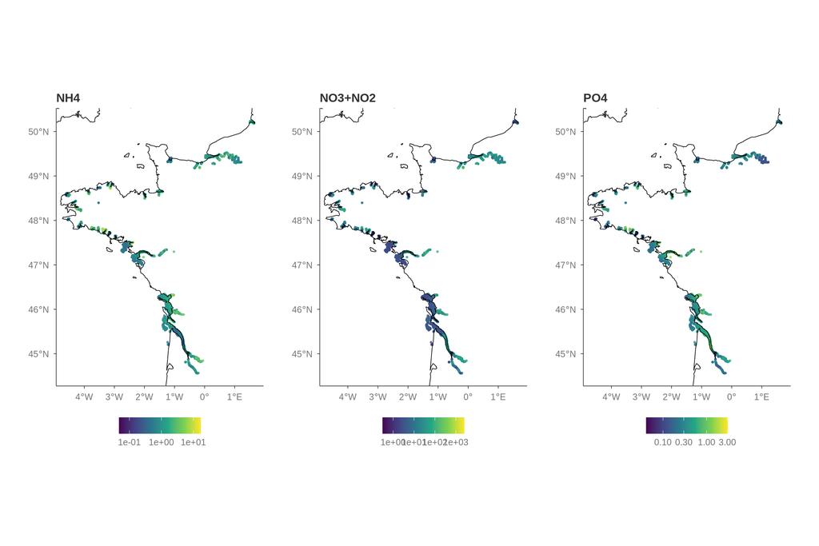

```r
plot_operation_map <- function(parameter, value_col, legend) {
  d <- foodweb_predictions |> dplyr::filter(parameter_code == parameter)
  ggplot(d, aes(longitude, latitude, color = .data[[value_col]])) +
    geom_point(size = 0.6, alpha = 0.7) +
    geom_sf(data = coastline(), inherit.aes = FALSE, linewidth = 0.3) +
    coord_sf(
      xlim = range(foodweb_predictions$longitude),
      ylim = range(foodweb_predictions$latitude)
    ) +
    scale_color_viridis_c(trans = if (value_col == "pred") "log10" else "identity") +
    labs(x = NULL, y = NULL, color = legend, title = parameter) +
    theme(panel.grid = element_blank())
}

patchwork::wrap_plots(
  lapply(c("NH4", "NO3+NO2", "PO4"), plot_operation_map, value_col = "pred", legend = NULL),
  nrow = 1
)
```

```r
foodweb_predictions |>
  dplyr::summarise(
    n = dplyr::n(),
    median = round(median(pred), 2),
    p10 = round(quantile(pred, 0.1), 2),
    p90 = round(quantile(pred, 0.9), 2),
    .by = c(parameter_code, survey)
  ) |>
  dplyr::arrange(parameter_code, survey) |>
  knitr::kable()
```

| parameter_code | survey | n | median | p10 | p90 |
| --- | --- | --- | --- | --- | --- |
| NH4 | nurse | 1471 | 0.67 | 0.37 | 1.32 |
| NH4 | pomet | 6523 | 1.42 | 0.50 | 4.10 |
| NO3+NO2 | nurse | 1471 | 3.12 | 2.04 | 4.62 |
| NO3+NO2 | pomet | 6523 | 22.59 | 3.10 | 72.89 |
| PO4 | nurse | 1471 | 0.28 | 0.19 | 0.44 |
| PO4 | pomet | 6523 | 0.38 | 0.15 | 1.10 |

### Prediction uncertainty

We next investigate the uncertainty of our predictions.

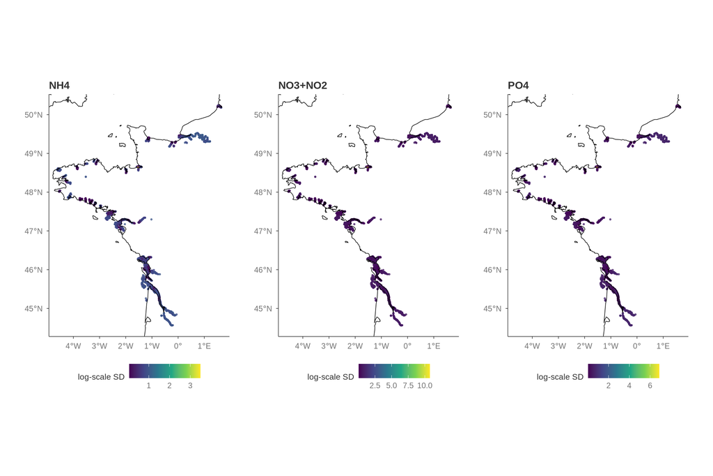

```r
patchwork::wrap_plots(
  lapply(
    c("NH4", "NO3+NO2", "PO4"), plot_operation_map,
    value_col = "sd", legend = "log-scale SD"
  ),
  nrow = 1
)
```

A quick demonstration, 200 draws for PO4 at 5 operations, from the cached fit:

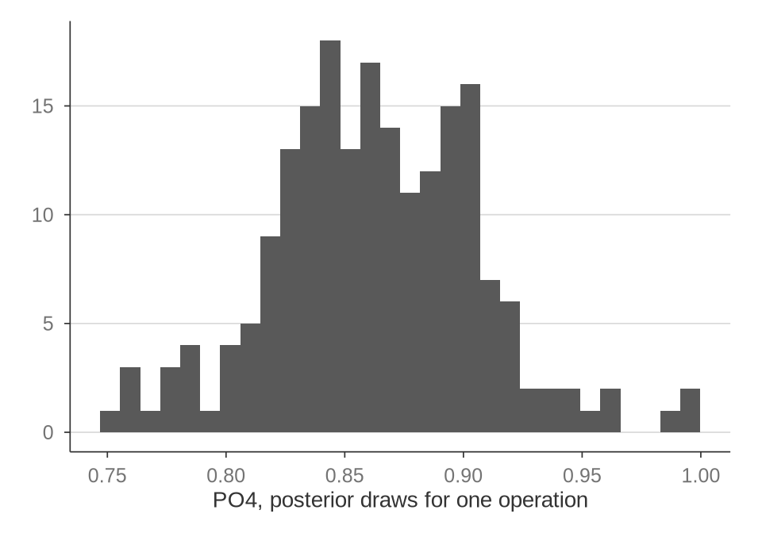

```r
fit_po4 <- tar_read(rephy_fit_po4)
draws_demo <- sample_rephy_spde_smooth(
  fit_po4,
  foodwebs |> dplyr::slice_sample(n = 5),
  n_draws = 200
)

ggplot(data.frame(draw = draws_demo[1, ]), aes(draw)) +
  geom_histogram(bins = 30) +
  labs(x = "PO4, posterior draws for one operation", y = NULL) +
  theme(panel.grid = element_blank())
```

## References

Diaz, Robert J., and Rutger Rosenberg. 2008. “Spreading Dead Zones and Consequences for Marine Ecosystems.” *Science* 321 (5891): 926–29. https://doi.org/10.1126/science.1156401.